# Project: Investigate a Medical Appointment No Shows Dataset

- Introduction
- Data Wrangling
- Exploratory Data Analysis
- Conclusions

## 1. Introduction

In this project, I explored the data regarding medical appointments in Brazil. The dataset, retrieved from Kaggle, contains information of more than 100,000 medical appointments, details about the patients, and whether they showed up for their appointments. The main aim of this project is to determine factors that could be associatied with the patients' likelihood of turning up for appointment and these are my research questions when conducting the analysis:

1. Does age influence the show up rate?
2. Which gender is more likely to show up for their appointments?
3. Does being handicap influence the show up rate of patients?
4. What impact does receiving SMS play in the likelihood of patients showing up?
5. Are patients under the Bolsa Família program more likely to show up?
6. Are hypertension, diabetes, or alcoholism related to the likelihood of patients showing up?

```python
import numpy as np
import pandas as pd
import matplotlib.pyplot as plt
import seaborn as sns
sns.set_style('darkgrid')

# This is to make visualisations plotted inline with the notebook
%matplotlib inline
```

## 2. Data Wrangling

### 2.1 General Properties

To begin, I loaded the data using pandas's read_csv command. To get a snapshot of how the dataset looks like, I also printed the first five rows of data.

```python
df = pd.read_csv('noshowappointments.csv')
df.head()
```

|  | PatientId | AppointmentID | Gender | ScheduledDay | AppointmentDay | Age | Neighbourhood | Scholarship | Hipertension | Diabetes | Alcoholism | Handcap | SMS_received | No-show |
| --- | --- | --- | --- | --- | --- | --- | --- | --- | --- | --- | --- | --- | --- | --- |
| 0 | 2.987250e+13 | 5642903 | F | 2016-04-29T18:38:08Z | 2016-04-29T00:00:00Z | 62 | JARDIM DA PENHA | 0 | 1 | 0 | 0 | 0 | 0 | No |
| 1 | 5.589978e+14 | 5642503 | M | 2016-04-29T16:08:27Z | 2016-04-29T00:00:00Z | 56 | JARDIM DA PENHA | 0 | 0 | 0 | 0 | 0 | 0 | No |
| 2 | 4.262962e+12 | 5642549 | F | 2016-04-29T16:19:04Z | 2016-04-29T00:00:00Z | 62 | MATA DA PRAIA | 0 | 0 | 0 | 0 | 0 | 0 | No |
| 3 | 8.679512e+11 | 5642828 | F | 2016-04-29T17:29:31Z | 2016-04-29T00:00:00Z | 8 | PONTAL DE CAMBURI | 0 | 0 | 0 | 0 | 0 | 0 | No |
| 4 | 8.841186e+12 | 5642494 | F | 2016-04-29T16:07:23Z | 2016-04-29T00:00:00Z | 56 | JARDIM DA PENHA | 0 | 1 | 1 | 0 | 0 | 0 | No |

Here are the descriptions of the columns as understood from the information in the Data Dictionary section in Kaggle,

- The **PatientId** column records the identification number of each patient.
- The **AppointmentID** column records the identification number of each medical appointment.
- The **ScheduledDay** column shows the date when the patient scheduled their appointments.
- The **AppointmentDay** column shows the date of the appointments.
- The **Neighbourhood** column shows the locations of the hospitals.
- The **Scholarship** column implies whether the patients are enrolled in a Brazilian welfare program called 'Bolsa Família' (**0** means no and **1** means yes).
- The **Hipertension**, **Diabetes**, and **Alcoholism** columns indicate whether the patients have hypertension, diabetes, or alcoholism, respectively (**0** means no and **1** means yes).
- The **Handcap** column indicates whether the patients have any handicap. Not much is explained on what each value means, so I assume that **0** means the patients do not have handicap, and any other value means that they do.
- The **SMS_received** column shows whether the patients received SMS notifications about their appointments (**0** means no and **1** means yes).
- The **No-show** column implies whether the patients were absent for their appointments. **'Yes'** means that they were **absent**, while **'No'** means that they **were not absent**. (i.e. they showed up for their appointments).

I noticed that there are two problems with the column names:

- Firstly, there was some spelling mistakes (Hipertension and Handcap).
- Secondly, The first two columns are not named consistently. In the first column, the term 'id' is spelled with an uppercase 'I' and a lowercase 'd', but in the second column both 'I' and 'D' are in uppercase.

So, I renamed the columns.

```python
df.rename(columns={'PatientId': 'PatientID', 'Hipertension': 'Hypertension', 'Handcap': 'Handicap'}, inplace=True)
```

Next, I checked the the number of rows and columns, the data type of each column, and number of missing values.

```python
df.info()
```

```
<class 'pandas.core.frame.DataFrame'>
RangeIndex: 110527 entries, 0 to 110526
Data columns (total 14 columns):
PatientID         110527 non-null float64
AppointmentID     110527 non-null int64
Gender            110527 non-null object
ScheduledDay      110527 non-null object
AppointmentDay    110527 non-null object
Age               110527 non-null int64
Neighbourhood     110527 non-null object
Scholarship       110527 non-null int64
Hypertension      110527 non-null int64
Diabetes          110527 non-null int64
Alcoholism        110527 non-null int64
Handicap          110527 non-null int64
SMS_received      110527 non-null int64
No-show           110527 non-null object
dtypes: float64(1), int64(8), object(5)
memory usage: 11.8+ MB
```

From the above, we can see that:

- There are 110,527 rows and 14 columns of data.
- There are no missing values.
- The data in the 'PatientID' column, which should be integers, are stored in float format.
- The data in 'ScheduledDay' and 'AppointmentDay' columns are stored in string format instead of datetime format.

After that, I checked for number of duplicates in the data.

```python
print(sum(df.duplicated()))
print(sum(df['PatientID'].duplicated()))
```

```
0
48228
```

This shows that there is no duplicate in the data and also some patients rebooked for appointments

### 2.2 Data Cleaning Part I: Column Names and Data Type

After exploring the dataset, there are a few areas of the dataset that need to be checked and cleaned:

- The data in the 'PatientID' column are stored using floats instead of integers.
- The data in 'ScheduledDay' and 'AppointmentDay' columns are stored in string format instead of datetime format.
- The appointment times are all at 00:00:00, which indicate that the patients arrange their appointments to be at 12 midnight.

This seems unusual because people probably do not go for medical appointments at that timing. With that in mind, I proceeded to clean the data

#### 2.2.1 Converting the Data Type of the 'PatientID' to Integers

```python
# Converting data type
df['PatientID'] = df['PatientID'].astype('int64')
# Check to see if the conversion was successful
df.head(1)
```

|  | PatientID | AppointmentID | Gender | ScheduledDay | AppointmentDay | Age | Neighbourhood | Scholarship | Hypertension | Diabetes | Alcoholism | Handicap | SMS_received | No-show |
| --- | --- | --- | --- | --- | --- | --- | --- | --- | --- | --- | --- | --- | --- | --- |
| 0 | 29872499824296 | 5642903 | F | 2016-04-29T18:38:08Z | 2016-04-29T00:00:00Z | 62 | JARDIM DA PENHA | 0 | 1 | 0 | 0 | 0 | 0 | No |

#### 2.2.2 Converting the Data in 'ScheduledDay' Column to datetime Objects

```python
df['ScheduledDay'] = pd.to_datetime(df['ScheduledDay'])
df.head(1)
```

|  | PatientID | AppointmentID | Gender | ScheduledDay | AppointmentDay | Age | Neighbourhood | Scholarship | Hypertension | Diabetes | Alcoholism | Handicap | SMS_received | No-show |
| --- | --- | --- | --- | --- | --- | --- | --- | --- | --- | --- | --- | --- | --- | --- |
| 0 | 29872499824296 | 5642903 | F | 2016-04-29 18:38:08+00:00 | 2016-04-29T00:00:00Z | 62 | JARDIM DA PENHA | 0 | 1 | 0 | 0 | 0 | 0 | No |

#### 2.2.3 Assessing the 'AppointmentDay' Column

As people probably do not go for medical appointments at 12 midnight, there are two possibilities where the time records in the 'AppointmentDay' column are 00:00:00 :

- They were the results of typos and the time was recorded wrongly.
- Only the date for the appointment was recorded and the time was not recorded.

If the second possibilty is true, then all the time in the 'AppointmentDay' column will be 00:00:00. To verify this, I checked the unique values in the column.

```python
df['AppointmentDay'].unique()
```

```
array(['2016-04-29T00:00:00Z', '2016-05-03T00:00:00Z',
       '2016-05-10T00:00:00Z', '2016-05-17T00:00:00Z',
       '2016-05-24T00:00:00Z', '2016-05-31T00:00:00Z',
       '2016-05-02T00:00:00Z', '2016-05-30T00:00:00Z',
       '2016-05-16T00:00:00Z', '2016-05-04T00:00:00Z',
       '2016-05-19T00:00:00Z', '2016-05-12T00:00:00Z',
       '2016-05-06T00:00:00Z', '2016-05-20T00:00:00Z',
       '2016-05-05T00:00:00Z', '2016-05-13T00:00:00Z',
       '2016-05-09T00:00:00Z', '2016-05-25T00:00:00Z',
       '2016-05-11T00:00:00Z', '2016-05-18T00:00:00Z',
       '2016-05-14T00:00:00Z', '2016-06-02T00:00:00Z',
       '2016-06-03T00:00:00Z', '2016-06-06T00:00:00Z',
       '2016-06-07T00:00:00Z', '2016-06-01T00:00:00Z',
       '2016-06-08T00:00:00Z'], dtype=object)
```

From the above, we can confirm that all the time is at 00:00:00. This implies that the time records are not an issue of typing mistakes. Therefore, I proceeded to convert the data in this column to datetime objects.

```python
df['AppointmentDay'] = pd.to_datetime(df['AppointmentDay'])
df.head(2)
```

|  | PatientID | AppointmentID | Gender | ScheduledDay | AppointmentDay | Age | Neighbourhood | Scholarship | Hypertension | Diabetes | Alcoholism | Handicap | SMS_received | No-show |
| --- | --- | --- | --- | --- | --- | --- | --- | --- | --- | --- | --- | --- | --- | --- |
| 0 | 29872499824296 | 5642903 | F | 2016-04-29 18:38:08+00:00 | 2016-04-29 00:00:00+00:00 | 62 | JARDIM DA PENHA | 0 | 1 | 0 | 0 | 0 | 0 | No |
| 1 | 558997776694438 | 5642503 | M | 2016-04-29 16:08:27+00:00 | 2016-04-29 00:00:00+00:00 | 56 | JARDIM DA PENHA | 0 | 0 | 0 | 0 | 0 | 0 | No |

### 2.3 Data Cleaning Part II: Checking Numeric Values

After the initial cleaning, I checked the values in the columns containing numeric data, i.e. 'Age', 'Scholarship', 'Hypertension', 'Diabetes', 'Alcoholism', 'Handicap', and 'SMS_received' to see if there are any areas that need to be cleaned.

#### 2.3.1 Age

```python
# Check the values in the 'Age' column
np.sort(df['Age'].unique())
```

```
array([ -1,   0,   1,   2,   3,   4,   5,   6,   7,   8,   9,  10,  11,
        12,  13,  14,  15,  16,  17,  18,  19,  20,  21,  22,  23,  24,
        25,  26,  27,  28,  29,  30,  31,  32,  33,  34,  35,  36,  37,
        38,  39,  40,  41,  42,  43,  44,  45,  46,  47,  48,  49,  50,
        51,  52,  53,  54,  55,  56,  57,  58,  59,  60,  61,  62,  63,
        64,  65,  66,  67,  68,  69,  70,  71,  72,  73,  74,  75,  76,
        77,  78,  79,  80,  81,  82,  83,  84,  85,  86,  87,  88,  89,
        90,  91,  92,  93,  94,  95,  96,  97,  98,  99, 100, 102, 115],
      dtype=int64)
```

We can see that there is a -1 value in the 'Age' column, which is most likely a typing mistake. To check whether this is true, I counted the number of occurrence of -1 in the column.

```python
df[df['Age'] == -1].count()['Age']
```

```
1
```

```python
# Find out which row contains the value -1 in the Age column.
df.loc[df['Age'] == -1]
```

|  | PatientID | AppointmentID | Gender | ScheduledDay | AppointmentDay | Age | Neighbourhood | Scholarship | Hypertension | Diabetes | Alcoholism | Handicap | SMS_received | No-show |
| --- | --- | --- | --- | --- | --- | --- | --- | --- | --- | --- | --- | --- | --- | --- |
| 99832 | 465943158731293 | 5775010 | F | 2016-06-06 08:58:13+00:00 | 2016-06-06 00:00:00+00:00 | -1 | ROMÃO | 0 | 0 | 0 | 0 | 0 | 0 | No |

```python
# Drop row 99832, which carries the value -1.
df.drop(index=99832, inplace=True)
```

```python
# Check to see if the row has been dropped successfully.
np.sort(df['Age'].unique())
```

```
array([  0,   1,   2,   3,   4,   5,   6,   7,   8,   9,  10,  11,  12,
        13,  14,  15,  16,  17,  18,  19,  20,  21,  22,  23,  24,  25,
        26,  27,  28,  29,  30,  31,  32,  33,  34,  35,  36,  37,  38,
        39,  40,  41,  42,  43,  44,  45,  46,  47,  48,  49,  50,  51,
        52,  53,  54,  55,  56,  57,  58,  59,  60,  61,  62,  63,  64,
        65,  66,  67,  68,  69,  70,  71,  72,  73,  74,  75,  76,  77,
        78,  79,  80,  81,  82,  83,  84,  85,  86,  87,  88,  89,  90,
        91,  92,  93,  94,  95,  96,  97,  98,  99, 100, 102, 115],
      dtype=int64)
```

#### 2.3.2 Scholarship, Hypertension, Diabetes, Alcoholism, Handicap, and SMS_received

```python
# Print the unique values in the columns
print('Scholarship:')
print(df['Scholarship'].unique())
print('Hypertension:')
print(df['Hypertension'].unique())
print('Diabetes:')
print(df['Diabetes'].unique())
print('Alcoholism:')
print(df['Alcoholism'].unique())
print('Handicap:')
print(df['Handicap'].unique())
print('SMS_received:')
print(df['SMS_received'].unique())
```

```
Scholarship:
[0 1]
Hypertension:
[1 0]
Diabetes:
[0 1]
Alcoholism:
[0 1]
Handicap:
[0 1 2 3 4]
SMS_received:
[0 1]
```

It seems that these columns do not have any values that appear unusual, so I did not conduct any further data cleaning on them and proceeded to conduct my analysis.

## 3. Exploratory Data Analysis

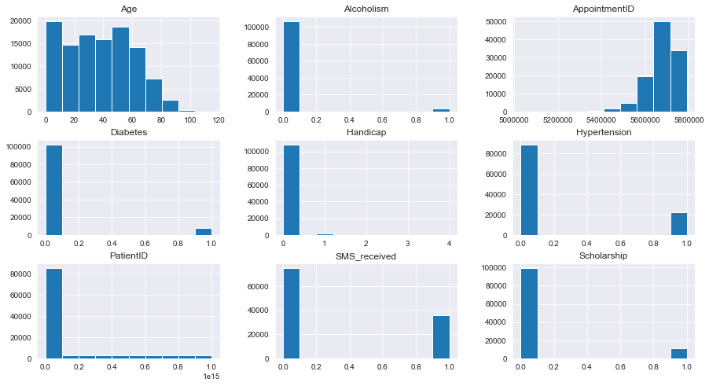

```python
# lets look at the general distribution of the whole columns
df.hist(figsize=(15, 8));
```

From the above, we can see that most of the patients

- are bellow 60 years old
- doesn't suffer from alcoholism/diabetes/hipertension
- are not handicapped
- doesn't received a reminder sms
- aren't in the "Bolsa familia" program
- doesn't missed the appointment

### 3.1 Does age influence the show up rate?

To examine this,let's start by looking at the minimum and maximum age.

```python
df['Age'].describe()
```

```
count    110526.000000
mean         37.089219
std          23.110026
min           0.000000
25%          18.000000
50%          37.000000
75%          55.000000
max         115.000000
Name: Age, dtype: float64
```

Next, I grouped the patients by age ranges of 20 and created a new column called 'AgeGroup'.

```python
# Set bin edges that will be used to "cut" the data into age groups
bin_edges = [0, 20, 40, 60, 80, 115]
# Create labels for each age group
bin_names = ['<20', '20-39', '40-59', '60-79', '>=80']

# Create the 'AgeGroup' column
df['AgeGroup'] = pd.cut(df['Age'], bin_edges, labels=bin_names, right=False, include_lowest=True)

df.head()
```

|  | PatientID | AppointmentID | Gender | ScheduledDay | AppointmentDay | Age | Neighbourhood | Scholarship | Hypertension | Diabetes | Alcoholism | Handicap | SMS_received | No-show | AgeGroup |
| --- | --- | --- | --- | --- | --- | --- | --- | --- | --- | --- | --- | --- | --- | --- | --- |
| 0 | 29872499824296 | 5642903 | F | 2016-04-29 18:38:08+00:00 | 2016-04-29 00:00:00+00:00 | 62 | JARDIM DA PENHA | 0 | 1 | 0 | 0 | 0 | 0 | No | 60-79 |
| 1 | 558997776694438 | 5642503 | M | 2016-04-29 16:08:27+00:00 | 2016-04-29 00:00:00+00:00 | 56 | JARDIM DA PENHA | 0 | 0 | 0 | 0 | 0 | 0 | No | 40-59 |
| 2 | 4262962299951 | 5642549 | F | 2016-04-29 16:19:04+00:00 | 2016-04-29 00:00:00+00:00 | 62 | MATA DA PRAIA | 0 | 0 | 0 | 0 | 0 | 0 | No | 60-79 |
| 3 | 867951213174 | 5642828 | F | 2016-04-29 17:29:31+00:00 | 2016-04-29 00:00:00+00:00 | 8 | PONTAL DE CAMBURI | 0 | 0 | 0 | 0 | 0 | 0 | No | <20 |
| 4 | 8841186448183 | 5642494 | F | 2016-04-29 16:07:23+00:00 | 2016-04-29 00:00:00+00:00 | 56 | JARDIM DA PENHA | 0 | 1 | 1 | 0 | 0 | 0 | No | 40-59 |

I proceed to group the patients by their respective age groups and find out the ratio of patients in each group that showed up.

```python
age_group_counts = df.groupby(['AgeGroup', 'No-show']).count()['Age']
age_group_counts
```

```
AgeGroup  No-show
<20       No         23670
          Yes         6741
20-39     No         22190
          Yes         6680
40-59     No         24416
          Yes         5656
60-79     No         15118
          Yes         2692
>=80      No          2811
          Yes          547
Name: Age, dtype: int64
```

```python
# Calculate proportion of patients that show up according to age groups
below_twenty = age_group_counts['<20', 'No'] / df['AgeGroup'].value_counts()['<20']

twenty_to_thirty_nine = age_group_counts['20-39', 'No'] / df['AgeGroup'].value_counts()['20-39']

forty_to_fifty_nine = age_group_counts['40-59', 'No'] / df['AgeGroup'].value_counts()['40-59']

sixty_to_seventy_nine = age_group_counts['60-79', 'No'] / df['AgeGroup'].value_counts()['60-79']

eighty_and_above = age_group_counts['>=80', 'No'] / df['AgeGroup'].value_counts()['>=80']
```

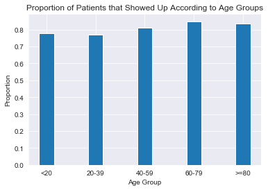

```python
# Plot the graph accordingly
proportions = [below_twenty, twenty_to_thirty_nine, forty_to_fifty_nine, sixty_to_seventy_nine, eighty_and_above]
plt.bar([1, 2, 3, 4, 5], proportions, width=0.3)
plt.xlabel('Age Group')
plt.ylabel('Proportion')
plt.xticks([1, 2, 3, 4, 5], ['<20', '20-39', '40-59', '60-79', '>=80'])
plt.title('Proportion of Patients that Showed Up According to Age Groups');
```

There seems to be some association between age groups and the show up rate of patients. Those that are below 40 years old are less likely to show up.

### 3.2 Which gender is more likely to show up for their appointments?

```python
# Count the number of patients of each gender
df['Gender'].value_counts()
```

```
F    71839
M    38687
Name: Gender, dtype: int64
```

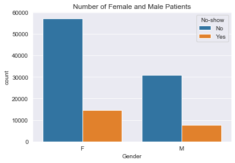

```python
sns.countplot(x='Gender', data=df, hue='No-show')
plt.title('Number of Female and Male Patients');
```

There are much more females than males that set up a medical appointment with the hospital, however, we cannot tell right now if gender influences the show-up rate because there no the distribution males and females is not equal. Let's dig deeper to get more insight.

```python
# Group patients by gender and whether they showed up
gender_counts = df.groupby(['Gender', 'No-show']).count()['Age']
gender_counts
```

```
Gender  No-show
F       No         57245
        Yes        14594
M       No         30962
        Yes         7725
Name: Age, dtype: int64
```

```python
female_show_up_proportion = gender_counts['F','No'] / df['Gender'].value_counts()['F']
female_show_up_proportion
```

```
0.7968512924734475
```

```python
male_show_up_proportion = gender_counts['M', 'No'] / df['Gender'].value_counts()['M']
male_show_up_proportion
```

```
0.8003205211052808
```

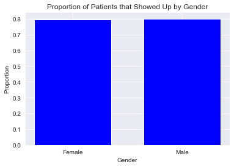

```python
plt.bar([1, 2],[female_show_up_proportion, male_show_up_proportion], width=0.7, color = 'b')
plt.xlabel('Gender')
plt.ylabel('Proportion')
plt.xticks([1, 2], ['Female', 'Male'])
plt.title('Proportion of Patients that Showed Up by Gender');
```

From the above figure,it is obvious that females and males are similarly likely to show up, which means that gender is most likely not associated with their show up rate.

### 3.3 Does being handicap influence the show up rate of patients?

```python
handicap_counts = df.groupby(['Handicap', 'No-show']).count()['Age']
handicap_counts
```

```
Handicap  No-show
0         No         86373
          Yes        21912
1         No          1676
          Yes          366
2         No           146
          Yes           37
3         No            10
          Yes            3
4         No             2
          Yes            1
Name: Age, dtype: int64
```

```python
handicap_zero = handicap_counts[0, 'No'] / df['Handicap'].value_counts()[0]
handicap_zero
```

```
0.7976451031998891
```

```python
handicap_one = handicap_counts[1, 'No'] / df['Handicap'].value_counts()[1]
handicap_one
```

```
0.8207639569049952
```

```python
handicap_two = handicap_counts[2, 'No'] / df['Handicap'].value_counts()[2]
handicap_two
```

```
0.7978142076502732
```

```python
handicap_three = handicap_counts[3, 'No'] / df['Handicap'].value_counts()[3]
handicap_three
```

```
0.7692307692307693
```

```python
handicap_four = handicap_counts[4, 'No'] / df['Handicap'].value_counts()[4]
handicap_four
```

```
0.6666666666666666
```

After calculating the ratios of patients who showed up, grouped by their handicap types, I plotted the graph showing each ratio:

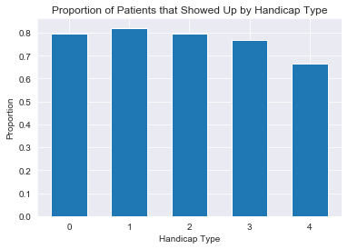

```python
plt.bar([1, 2, 3, 4, 5], [handicap_zero, handicap_one, handicap_two, handicap_three, handicap_four], width=0.6)
plt.xlabel('Handicap Type')
plt.ylabel('Proportion')
plt.xticks([1, 2, 3, 4, 5], ['0', '1', '2', '3', '4'])
plt.title('Proportion of Patients that Showed Up by Handicap Type');
```

We can see that the proportion of patients with handicap type 3 and 4 that showed up are lower. This means that handicap types could be associated with the likelihood of patients showing up. However, it is important to note that there are much fewer patients with those handicap types (13 patients with type 3, 3 patients with type 4), so the association might not be as strong as shown in the graph above.

### 3.4 What impact does receiving SMS play in the likelihood of patients showing up?

```python
sms_counts = df.groupby(['SMS_received', 'No-show']).count()['Age']
sms_counts
```

```
SMS_received  No-show
0             No         62509
              Yes        12535
1             No         25698
              Yes         9784
Name: Age, dtype: int64
```

```python
no_sms_show_up_proportion = sms_counts[0, 'No'] / df['SMS_received'].value_counts()[0]
no_sms_show_up_proportion
```

```
0.8329646607323703
```

```python
sms_show_up_proportion = sms_counts[1, 'No'] / df['SMS_received'].value_counts()[1]
sms_show_up_proportion
```

```
0.7242545516036301
```

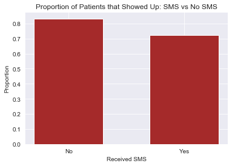

```python
plt.bar([1, 2], [no_sms_show_up_proportion, sms_show_up_proportion], width=0.6, color=['brown'])
plt.xlabel('Received SMS')
plt.ylabel('Proportion')
plt.xticks([1, 2], ['No', 'Yes'])
plt.title('Proportion of Patients that Showed Up: SMS vs No SMS');
```

It appears that the proportion of patients that received SMS notifications that showed up are lower than those that did not receive any notification.

### 3.5 Are patients under the Bolsa Família program more likely to show up?

The Bolsa Família Program is a social welfare program in Brazil that provides financial support to poor families. To see whether receiving the support helps to encourage patients to go for their appointments, I grouped the patients according to their enrolment in the program and compared the proportion of people who showed up among these two groups

```python
scholarship_counts = df.groupby(['Scholarship', 'No-show']).count()['Age']
scholarship_counts
```

```
Scholarship  No-show
0            No         79924
             Yes        19741
1            No          8283
             Yes         2578
Name: Age, dtype: int64
```

```python
not_enrolled_show_up_proportion = scholarship_counts[0, 'No'] / df['Scholarship'].value_counts()[0]
not_enrolled_show_up_proportion
```

```
0.8019264536196258
```

```python
enrolled_show_up_proportion = scholarship_counts[1, 'No'] / df['Scholarship'].value_counts()[1]
enrolled_show_up_proportion
```

```
0.7626369579228433
```

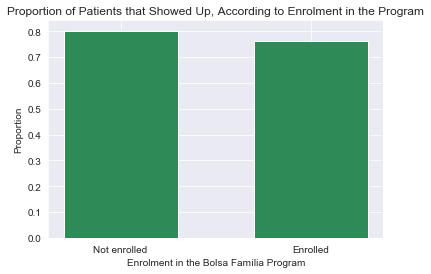

```python
plt.bar([1, 2], [not_enrolled_show_up_proportion, enrolled_show_up_proportion], width=0.6, color=['seagreen'])
plt.xlabel('Enrolment in the Bolsa Família Program')
plt.ylabel('Proportion')
plt.xticks([1, 2], ['Not enrolled', 'Enrolled'])
plt.title('Proportion of Patients that Showed Up, According to Enrolment in the Program');
```

It seems that patients enrolled in the Bolsa Família Program are slightly less likely to show up for their scheduled appointments. This implies that there might be some negative association between the program and the patient show up rate.

### 3.6 Are hypertension, diabetes, or alcoholism related to the likelihood of patients showing up?

Proportion of people who showed up, grouped by hypertension:

```python
hypertension_counts = df.groupby(['Hypertension', 'No-show']).count()['Age']
hypertension_counts
```

```
Hypertension  No-show
0             No         70178
              Yes        18547
1             No         18029
              Yes         3772
Name: Age, dtype: int64
```

```python
non_hypertensive = hypertension_counts[0, 'No'] / df['Hypertension'].value_counts()[0]
hypertensive = hypertension_counts[1, 'No'] / df['Hypertension'].value_counts()[1]
```

Proportion of people who showed up, grouped by diabetes:

```python
diabetes_counts = df.groupby(['Diabetes', 'No-show']).count()['Age']
diabetes_counts
```

```
Diabetes  No-show
0         No         81694
          Yes        20889
1         No          6513
          Yes         1430
Name: Age, dtype: int64
```

```python
non_diabetic = diabetes_counts[0, 'No'] / df['Diabetes'].value_counts()[0]
diabetic = diabetes_counts[1, 'No'] / df['Diabetes'].value_counts()[1]
```

Proportion of people who showed up, grouped by alcoholism:

```python
alcoholism_counts = df.groupby(['Alcoholism', 'No-show']).count()['Age']
alcoholism_counts
```

```
Alcoholism  No-show
0           No         85524
            Yes        21642
1           No          2683
            Yes          677
Name: Age, dtype: int64
```

```python
non_alcoholic = alcoholism_counts[0, 'No'] / df['Alcoholism'].value_counts()[0]
alcoholic = alcoholism_counts[1, 'No'] / df['Alcoholism'].value_counts()[1]
```

After calculating the ratio of patients who showed up, grouped by their conditions, I plotted the graph showing each ratio:

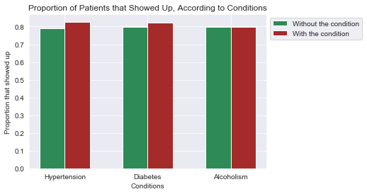

```python
ind = np.array([1, 2, 3])
width = 0.3
plt.bar(ind, [non_hypertensive, non_diabetic, non_alcoholic], width=width, color='seagreen', label='Without the condition')
plt.bar(ind+width, [hypertensive, diabetic, alcoholic], width=width, color='brown', label='With the condition')

plt.xlabel('Conditions')
plt.ylabel('Proportion that showed up')

locations = ind + width / 2
plt.xticks(locations, ['Hypertension', 'Diabetes', 'Alcoholism'])
plt.title('Proportion of Patients that Showed Up, According to Conditions')

plt.legend(bbox_to_anchor=(1,1));
```

From the graph, we can see that patients with hypertension or diabetes are more likely to turn up for their appointments compared to those who do not have those conditions. This indicates that there could be some association between these conditions and the patients' probability of showing up. On the other hand, alcoholism does not seem to have much effect on whether patients show up.

## 4 Conclusions

After conducting the analyses, I found that there is some association between patients' likelihood of showing up and these variables:

- Age
- Hypertension
- Diabetes
- Handicap type
- Scholarship (i.e. the Bolsa Família welfare program)
- SMS

There are also two surprising findings:

The Bolsa Família welfare program did not help to increase the show up rate. In fact, there is a lower proportion of patients enrolled in the program that showed up. Those that received SMS about their appointments are also less likely to show up.

However, these findings are only tentative. Statistical tests will be needed to explore the significance of these associations. Apart from that, the lack of information about the meaning of different values in each column also hindered the inferences that could be made during the analysis. In the Handicap column, not much detail is given on what each value means, so I made the assumption that **0** means the patients do not have handicap, and the other values refer to different types of handicap. The different values could also possibly mean levels or severity of handicap, but without more information I could not be sure. Also, in the columns that contain only values **0** and **1**, such as Scholarship and Hypertension, there is no explanation of the meaning of each value, so I assumed that **0** means false/no and **1** means true/yes. If the values mean otherwise, the conclusion made from this analysis will have to be changed. Therefore, to better understand the relationship between the patients' show up rate and the other variables, statistical tests and clarification on the meaning of different values in the columns are required.

```python
from subprocess import call
call(['python', '-m', 'nbconvert', 'Investigate_a_Dataset.ipynb'])
```

```
0
```